# Course Project

Paco López Dekker

Tuesday, February 17, 2015

This is the write-up for Practical Machine Learning Course project.

# Summary

## Things done

- Removed some useless information or information that I choose not to use (like the names of the users, which could help the prediction but would make the models not applicable to new users).
- Separated data in training and testing data sets.
- Inspected data using feature plots to look for promising indicators. Made a list of most promising ones.
- Did some basic pre-processing (scaling and centering).
- Trained several models using selected indicators using Boosting (gbm) and Random Forest and with simple decission trees.
- Did a Principal Component Analysis, with two threshold levels (0.9 and 0.95)
- Trained several models using selected indicators using Boosting (gbm and Ada Boost) and Random Forest.

# Data preparation

First we read the data from the csv source.

```r
library(caret); library(ggplot2);
pml_dir <- "C:/Users/lope_fr/Documents/Calaix/Coursera/MachineLearning"
setwd(pml_dir)
HARdata_raw = read.csv("pml-training.csv")
```

Because some of the training algorithms need long computation times, I have saved some of the models in files. Here I set a Boolean variable to load the stored modeld or redo the training

```r
use_saved <- TRUE
set.seed(1234)
```

Now let us sanitize the data a bit by removing the NA dominated columns. We will also try to remove information tha could be correlated with the outcome without being useful for a general model: user_name, timetamps

```r
na_count <- colSums(is.na(HARdata_raw))
na_cols <- which(na_count > dim(HARdata_raw)[1]/2)
HARdata <- HARdata_raw[, -na_cols]
HARdata <- HARdata[,-c(1,2,3,4,5,6,7)]
rm(HARdata_raw)
```

Create typical training and testing data set

```r
inTrain <- createDataPartition(y=HARdata$classe, p=0.6, list=FALSE)
HARtraining <- HARdata[inTrain,]
HARtesting <- HARdata[-inTrain,]
```

Inspection of variables using featureplots to look for obvious indicators. Things that seem useful: (roll_arm, pitch_arm, yaw_arm) (roll_forearm, pitch_forearm, yaw_forearm) maybe (accel_arm_x, accel_arm_y, accel_arm_z) total_accel_dumbbell (accel_dumbbell_x, accel_arm_y, accel_dumbbell_z) (magnet_dumbbell_x, magne_dumbbell_y, magnet_dumbbell_z) For example:

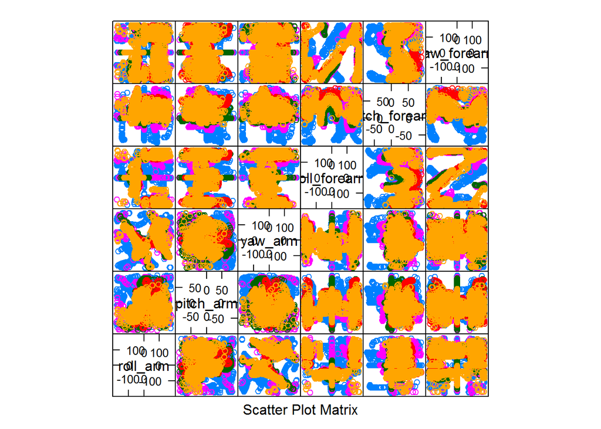

```r
clear_feat <- c("roll_arm", "pitch_arm", "yaw_arm", "roll_forearm", "pitch_forearm", "yaw_forearm")
maybe_feat <- c("accel_arm_x", "accel_arm_y", "accel_arm_z", "total_accel_dumbbell",
                "accel_dumbbell_x","accel_dumbbell_y", "accel_dumbbell_z",
                "magnet_dumbbell_x", "magnet_dumbbell_y", "magnet_dumbbell_z")
sel_feat <- c(clear_feat, maybe_feat)
featurePlot(x=HARtraining[,clear_feat],y=HARtraining$classe,plot="pairs")
```

Now lets try a tree partition predictor based on identified features

```r
clearTree <- train(HARtraining[,clear_feat],HARtraining$classe, method="rpart")
selTree <- train(HARtraining[,sel_feat],HARtraining$classe, method="rpart")
```

And we can look a bit at how they are doing in sample

```r
pred_clear_training <- predict(clearTree,HARtraining)
pred_sel_training <- predict(selTree,HARtraining)
table(pred_clear_training,HARtraining$classe)
```

```
##
## pred_clear_training    A    B    C    D    E
##                   A 2854 1119  786  589  662
##                   B    0    0    0    0    0
##                   C  247  742 1063  726  958
##                   D  247  418  205  615  545
##                   E    0    0    0    0    0
```

```r
table(pred_sel_training,HARtraining$classe)
```

```
##
## pred_sel_training    A    B    C    D    E
##                 A 3029  889  933  850  704
##                 B   69  824   71  367  680
##                 C  179  264  926  287  505
##                 D   71  302  124  426  276
##                 E    0    0    0    0    0
```

Or see the predicted performance by the training algorithm

```r
print(clearTree)
```

```
## CART
##
## 11776 samples
##     6 predictor
##     5 classes: 'A', 'B', 'C', 'D', 'E'
##
## No pre-processing
## Resampling: Bootstrapped (25 reps)
##
## Summary of sample sizes: 11776, 11776, 11776, 11776, 11776, 11776, ...
##
## Resampling results across tuning parameters:
##
##   cp          Accuracy   Kappa      Accuracy SD  Kappa SD
##   0.02835785  0.3900970  0.2082023  0.01529338   0.02651142
##   0.04366398  0.3716135  0.1779838  0.01564018   0.03014525
##   0.04841006  0.3205802  0.0747527  0.04258794   0.08215033
##
## Accuracy was used to select the optimal model using  the largest value.
## The final value used for the model was cp = 0.02835785.
```

```r
print(selTree)
```

```
## CART
##
## 11776 samples
##    16 predictor
##     5 classes: 'A', 'B', 'C', 'D', 'E'
##
## No pre-processing
## Resampling: Bootstrapped (25 reps)
##
## Summary of sample sizes: 11776, 11776, 11776, 11776, 11776, 11776, ...
##
## Resampling results across tuning parameters:
##
##   cp          Accuracy   Kappa       Accuracy SD  Kappa SD
##   0.03037494  0.4441643  0.27221776  0.01593163   0.02093693
##   0.03583294  0.4327236  0.25641801  0.01394877   0.01825674
##   0.06150134  0.3303347  0.08232833  0.06316761   0.11211694
##
## Accuracy was used to select the optimal model using  the largest value.
## The final value used for the model was cp = 0.03037494.
```

## Basic Preprocessing

I do some centering and scaling of the scalable features. Here I also have removed “factor” features after realizing that they had no values for most of the rows in the data set. Probably this scaling was not really needed, since the method used are based on decision trees, but it will not hurt and it may be useful for some algorithms.

```r
training_classe <- HARtraining$classe
testing_classe <- HARtesting$classe
feat_cols <- which(colnames(HARtraining) != "classe")
scalable_cols = which(sapply(HARtraining[,feat_cols], class) != "factor")
preCenterScale <- preProcess(HARtraining[,scalable_cols],method=c("center","scale"))
HARtraining <- predict(preCenterScale,HARtraining[,scalable_cols])
HARtesting <- predict(preCenterScale,HARtesting[,scalable_cols])
HARtraining$classe <- training_classe
HARtesting$classe <- testing_classe
feat_cols <- which(colnames(HARtraining) != "classe")
```

Now lets try boosting with the selected feature set (later we do PCA). Using gmb, since with the PCA reduced variables it seems to work better (see further below)

```r
if (use_saved) {
  load("sel_gbmBoostClassifier.Rdata")
} else {
  sel_gbmBoostClassifier <- train(HARtraining[,sel_feat], training_classe,
                                  method="gbm",verbose=FALSE)
  save(sel_gbmBoostClassifier,file="sel_gbmBoostClassifier.Rdata")
}
print(sel_gbmBoostClassifier)
```

```
## Stochastic Gradient Boosting
##
## 11776 samples
##    16 predictor
##     5 classes: 'A', 'B', 'C', 'D', 'E'
##
## No pre-processing
## Resampling: Bootstrapped (25 reps)
##
## Summary of sample sizes: 11776, 11776, 11776, 11776, 11776, 11776, ...
##
## Resampling results across tuning parameters:
##
##   interaction.depth  n.trees  Accuracy   Kappa      Accuracy SD
##   1                   50      0.6029885  0.4952903  0.010175653
##   1                  100      0.6646950  0.5742351  0.008535796
##   1                  150      0.7010650  0.6206927  0.007829857
##   2                   50      0.7233348  0.6483282  0.008181402
##   2                  100      0.7823496  0.7238860  0.007428120
##   2                  150      0.8105344  0.7598269  0.007509188
##   3                   50      0.7758114  0.7153208  0.007389586
##   3                  100      0.8288813  0.7831094  0.006507976
##   3                  150      0.8566405  0.8184481  0.006674200
##   Kappa SD
##   0.013095747
##   0.010977192
##   0.010042622
##   0.010447185
##   0.009346791
##   0.009504401
##   0.009349227
##   0.008204369
##   0.008437095
##
## Tuning parameter 'shrinkage' was held constant at a value of 0.1
## Accuracy was used to select the optimal model using  the largest value.
## The final values used for the model were n.trees = 150,
##  interaction.depth = 3 and shrinkage = 0.1.
```

Alternatively, let us see how the random forest performs. There are many available in caret, but let us just stick to the one used in the course.

```r
if (use_saved) {
  load('sel_rfClassifier.Rdata')
} else {
  sel_rfClassifier <- train(HARtraining[,sel_feat], training_classe, method="rf",
                            trControl=trainControl(method="cv",number=5),
                            prox=TRUE,allowParallel=TRUE)
  save(sel_rfClassifier, file='sel_rfClassifier.Rdata')
}
print(sel_rfClassifier)
```

```
## Random Forest
##
## 11776 samples
##    16 predictor
##     5 classes: 'A', 'B', 'C', 'D', 'E'
##
## No pre-processing
## Resampling: Cross-Validated (5 fold)
##
## Summary of sample sizes: 9420, 9420, 9422, 9421, 9421
##
## Resampling results across tuning parameters:
##
##   mtry  Accuracy   Kappa      Accuracy SD  Kappa SD
##    2    0.9629752  0.9531477  0.003699102  0.004675627
##    9    0.9619564  0.9518604  0.003243434  0.004100726
##   16    0.9520210  0.9392938  0.006403896  0.008095717
##
## Accuracy was used to select the optimal model using  the largest value.
## The final value used for the model was mtry = 2.
```

And here we smile seeing the 96% predicted accuracy.

## Principal Components Analysis

Previously, we had reduced the set of features manually. Now lets do it blindly using preprocessing, see how well we do.

```r
if (use_saved) {
  load("prePCA.Rdata")
} else {
  prePCA <- preProcess(HARtraining[,feat_cols],method="pca",thres=0.95)
  save(prePCA, file="prePCA.Rdata")
}
HARtrainingPCA <- predict(prePCA,HARtraining[,feat_cols])
HARtestingPCA <- predict(prePCA,HARtesting[,feat_cols])
HARtrainingPCA$classe <- training_classe
HARtestingPCA$classe <- testing_classe
```

A second set with less principal components

```r
if (use_saved) {
  load("prePCA90.Rdata")
} else {
  prePCA90 <- preProcess(HARtraining[,feat_cols],method="pca",thres=0.9)
  save(prePCA90, file="prePCA90.Rdata")
}
HARtrainingPCA90 <- predict(prePCA90,HARtraining[,feat_cols])
HARtestingPCA90 <- predict(prePCA90,HARtesting[,feat_cols])
HARtrainingPCA90$classe <- training_classe
HARtestingPCA90$classe <- testing_classe
```

Now I try a simple decision tree with PCA

```r
PCATree <- train(classe ~ .,data=HARtrainingPCA, method="rpart")
pred_PCA_training <- predict(PCATree,HARtrainingPCA)
table(pred_PCA_training,training_classe)
```

```
##                  training_classe
## pred_PCA_training    A    B    C    D    E
##                 A 3075 1541 1936 1001 1151
##                 B    0    0    0    0    0
##                 C    0    0    0    0    0
##                 D  223  416   74  746  287
##                 E   50  322   44  183  727
```

As before, a simple tree does not seem to perform well. Let us try boosting using gbm, and Adaboost on the PCA tranformed data

```r
if (use_saved) {
  load("gbmBoostClassifier.Rdata")
} else {
  gbmBoostClassifier <- train(classe ~ ., method="gbm",data=HARtrainingPCA,
                              verbose=FALSE)
  save(gbmBoostClassifier,file="gbmBoostClassifier.Rdata")
}
if (use_saved) {
  load("AdaBoostClassifier.Rdata")
} else {
  AdaBoostClassifier <- train(classe ~ ., method="AdaBoost.M1",
                              data=HARtrainingPCA)
  save(AdaBoostClassifier,file="AdaBoostClassifier.Rdata")
}
print(gbmBoostClassifier)
```

```
## Stochastic Gradient Boosting
##
## 11776 samples
##    24 predictor
##     5 classes: 'A', 'B', 'C', 'D', 'E'
##
## No pre-processing
## Resampling: Bootstrapped (25 reps)
##
## Summary of sample sizes: 11776, 11776, 11776, 11776, 11776, 11776, ...
##
## Resampling results across tuning parameters:
##
##   interaction.depth  n.trees  Accuracy   Kappa      Accuracy SD
##   1                   50      0.5563294  0.4309881  0.008516607
##   1                  100      0.6133326  0.5070869  0.007775511
##   1                  150      0.6418211  0.5442213  0.007062769
##   2                   50      0.6510150  0.5560142  0.007829623
##   2                  100      0.7152886  0.6386865  0.008478686
##   2                  150      0.7538053  0.6879366  0.007729184
##   3                   50      0.7062789  0.6272039  0.007290110
##   3                  100      0.7712397  0.7100972  0.006688884
##   3                  150      0.8048847  0.7528866  0.007932315
##   Kappa SD
##   0.010755478
##   0.009840151
##   0.008975269
##   0.009956903
##   0.010862419
##   0.009812617
##   0.009113960
##   0.008417997
##   0.010087847
##
## Tuning parameter 'shrinkage' was held constant at a value of 0.1
## Accuracy was used to select the optimal model using  the largest value.
## The final values used for the model were n.trees = 150,
##  interaction.depth = 3 and shrinkage = 0.1.
```

```r
print(AdaBoostClassifier)
```

[output not shown]

[output cut: 18 more lines]

```
##   0.018611959
##   0.017525852
##   0.015444374
##   0.012329598
##   0.009994991
##   0.016383834
##   0.011797417
##   0.011400066
##   0.014750232
##   0.017176889
##   0.015437571
##
## Accuracy was used to select the optimal model using  the largest value.
## The final values used for the model were mfinal = 150, maxdepth = 3
##  and coeflearn = Zhu.
```

Here we learn that the gbm algorithm yields better results than Ada Boost for this particular problem. But also we see that working with the manually selected features was providing better results.

See again how the Random forest does (expected to do better)

```r
if (use_saved) {
  load("PCA_rfClassifier.Rdata")
} else {
  PCA_rfClassifier <- train(classe ~ ., data=HARtrainingPCA, method="rf",
                            trControl=trainControl(method="cv",number=5),
                            prox=TRUE,allowParallel=TRUE)
  save(PCA_rfClassifier,file="PCA_rfClassifier.Rdata")
}
print(PCA_rfClassifier)
```

```
## Random Forest
##
## 11776 samples
##    24 predictor
##     5 classes: 'A', 'B', 'C', 'D', 'E'
##
## No pre-processing
## Resampling: Cross-Validated (5 fold)
##
## Summary of sample sizes: 9420, 9421, 9421, 9421, 9421
##
## Resampling results across tuning parameters:
##
##   mtry  Accuracy   Kappa      Accuracy SD  Kappa SD
##    2    0.9625510  0.9526209  0.002962835  0.003743566
##   13    0.9565212  0.9450001  0.005722010  0.007217387
##   24    0.9470953  0.9330784  0.006406415  0.008080027
##
## Accuracy was used to select the optimal model using  the largest value.
## The final value used for the model was mtry = 2.
```

Which results in very similar performance to the random tree with hand selected features, but with apparently a more reliable estimate of the accuracy.

And for the second PCA set

```r
if (use_saved) {
  load("PCA90_rfClassifier.Rdata")
} else {
  PCA90_rfClassifier <- train(classe ~ ., data=HARtrainingPCA90, method="rf",
                              trControl=trainControl(method="cv",number=5),
                              prox=TRUE,allowParallel=TRUE)
  save(PCA90_rfClassifier,file="PCA90_rfClassifier.Rdata")
}
print(PCA90_rfClassifier)
```

```
## Random Forest
##
## 11776 samples
##    18 predictor
##     5 classes: 'A', 'B', 'C', 'D', 'E'
##
## No pre-processing
## Resampling: Cross-Validated (5 fold)
##
## Summary of sample sizes: 9421, 9421, 9420, 9421, 9421
##
## Resampling results across tuning parameters:
##
##   mtry  Accuracy   Kappa      Accuracy SD  Kappa SD
##    2    0.9596629  0.9489576  0.007629629  0.009659168
##   10    0.9532945  0.9409222  0.005786684  0.007316846
##   18    0.9420003  0.9266510  0.009623324  0.012177597
##
## Accuracy was used to select the optimal model using  the largest value.
## The final value used for the model was mtry = 2.
```

This seems to perform a bit worse.

# Testing

Now I do some testing for the two models that work best and, for illustration, for one that doesn’t work that well.

## Random Forest with hand-selected indicators

```r
sel_rf_test_pred <- predict(sel_rfClassifier, HARtesting[,sel_feat])
```

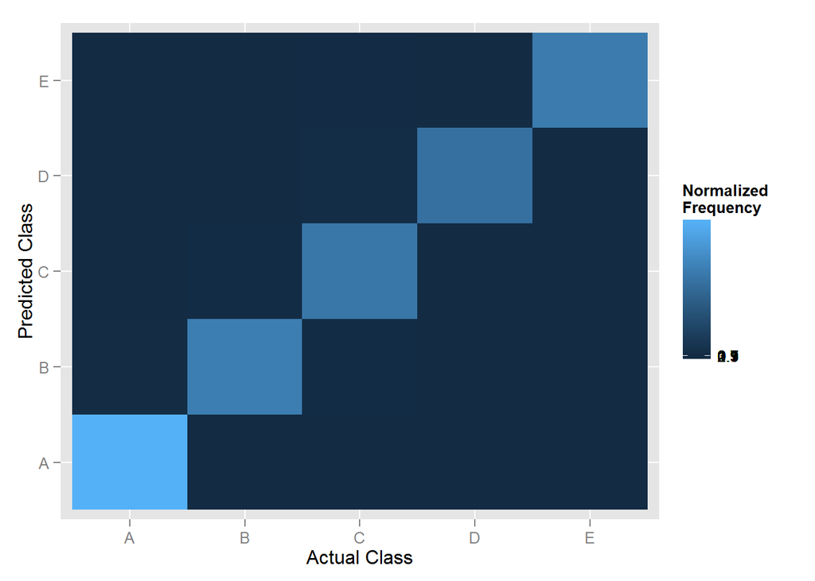

```r
sel_rf_confusion <-confusionMatrix(sel_rf_test_pred, testing_classe)
plot1 <- ggplot(as.data.frame(sel_rf_confusion$table))
plot1 + geom_tile(aes(x=Prediction, y=Reference, fill=Freq)) + scale_x_discrete(name="Actual Class") + scale_y_discrete(name="Predicted Class") + scale_fill_gradient(breaks=seq(from=-.5, to=4, by=.2)) + labs(fill="Normalized\nFrequency")
```

```r
print(sel_rf_confusion)
```

```
## Confusion Matrix and Statistics
##
##           Reference
## Prediction    A    B    C    D    E
##          A 2227   40    0    2    0
##          B    3 1437   30    1   13
##          C    0   29 1330   55   16
##          D    2    6    1 1214   23
##          E    0    6    7   14 1390
##
## Overall Statistics
##
##                Accuracy : 0.9684
##                  95% CI : (0.9643, 0.9722)
##     No Information Rate : 0.2845
##     P-Value [Acc > NIR] : < 2.2e-16
##
##                   Kappa : 0.96
##  Mcnemar's Test P-Value : NA
##
## Statistics by Class:
##
##                      Class: A Class: B Class: C Class: D Class: E
## Sensitivity            0.9978   0.9466   0.9722   0.9440   0.9639
## Specificity            0.9925   0.9926   0.9846   0.9951   0.9958
## Pos Pred Value         0.9815   0.9683   0.9301   0.9743   0.9809
## Neg Pred Value         0.9991   0.9873   0.9941   0.9891   0.9919
## Prevalence             0.2845   0.1935   0.1744   0.1639   0.1838
## Detection Rate         0.2838   0.1832   0.1695   0.1547   0.1772
## Detection Prevalence   0.2892   0.1891   0.1823   0.1588   0.1806
## Balanced Accuracy      0.9951   0.9696   0.9784   0.9696   0.9799
```

## Random Forest with Principal Components

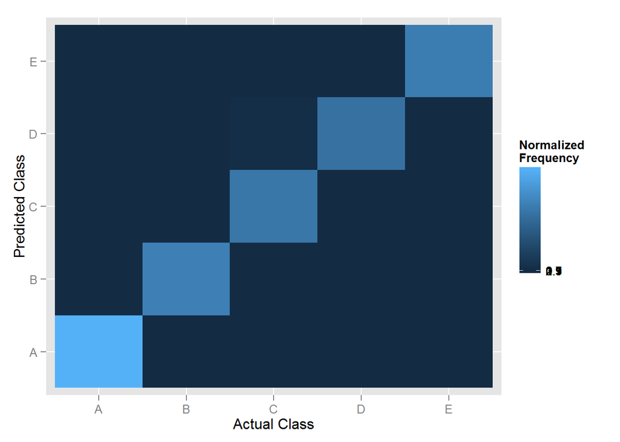

```r
PCA_rf_test_pred <- predict(PCA_rfClassifier, HARtestingPCA)
PCA_rf_confusion <- confusionMatrix(PCA_rf_test_pred, testing_classe)
plot2 <- ggplot(as.data.frame(PCA_rf_confusion$table))
plot2 + geom_tile(aes(x=Prediction, y=Reference, fill=Freq)) + scale_x_discrete(name="Actual Class") + scale_y_discrete(name="Predicted Class") + scale_fill_gradient(breaks=seq(from=-.5, to=4, by=.2)) + labs(fill="Normalized\nFrequency")
```

```r
print(PCA_rf_confusion)
```

```
## Confusion Matrix and Statistics
##
##           Reference
## Prediction    A    B    C    D    E
##          A 2214   24    5    5    0
##          B    4 1471   25    1    6
##          C    6   22 1325   57   14
##          D    8    0   13 1221    7
##          E    0    1    0    2 1415
##
## Overall Statistics
##
##                Accuracy : 0.9745
##                  95% CI : (0.9708, 0.9779)
##     No Information Rate : 0.2845
##     P-Value [Acc > NIR] : < 2.2e-16
##
##                   Kappa : 0.9677
##  Mcnemar's Test P-Value : NA
##
## Statistics by Class:
##
##                      Class: A Class: B Class: C Class: D Class: E
## Sensitivity            0.9919   0.9690   0.9686   0.9495   0.9813
## Specificity            0.9939   0.9943   0.9847   0.9957   0.9995
## Pos Pred Value         0.9849   0.9761   0.9305   0.9776   0.9979
## Neg Pred Value         0.9968   0.9926   0.9933   0.9901   0.9958
## Prevalence             0.2845   0.1935   0.1744   0.1639   0.1838
## Detection Rate         0.2822   0.1875   0.1689   0.1556   0.1803
## Detection Prevalence   0.2865   0.1921   0.1815   0.1592   0.1807
## Balanced Accuracy      0.9929   0.9817   0.9766   0.9726   0.9904
```

## gbm Boosting with Principal Compoments

This one will be worse, but it is included for illustration.

```r
PCA_gbm_test_pred <- predict(gbmBoostClassifier, HARtestingPCA)
```

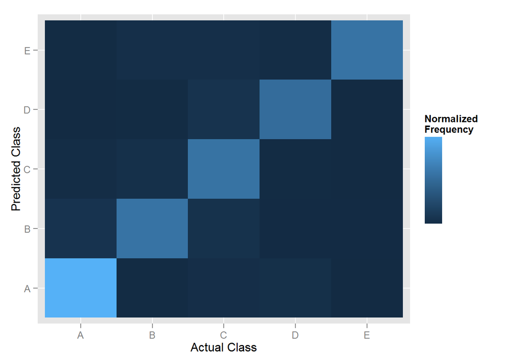

```r
PCA_gbm_confusion <- confusionMatrix(PCA_gbm_test_pred, testing_classe)
plot3 <- ggplot(as.data.frame(PCA_gbm_confusion$table))
plot3 + geom_tile(aes(x=Prediction, y=Reference, fill=Freq)) + scale_x_discrete(name="Actual Class") + scale_y_discrete(name="Predicted Class") + scale_fill_gradient(breaks=seq(from=-.5, to=4, by=.2)) + labs(fill="Normalized\nFrequency")
```

```r
print(PCA_gbm_confusion)
```

```
## Confusion Matrix and Statistics
##
##           Reference
## Prediction    A    B    C    D    E
##          A 1986  168   60   28   38
##          B   39 1140  114   39   98
##          C   84  142 1133  161  102
##          D  104   35   39 1039   66
##          E   19   33   22   19 1138
##
## Overall Statistics
##
##                Accuracy : 0.8203
##                  95% CI : (0.8116, 0.8287)
##     No Information Rate : 0.2845
##     P-Value [Acc > NIR] : < 2.2e-16
##
##                   Kappa : 0.7726
##  Mcnemar's Test P-Value : < 2.2e-16
##
## Statistics by Class:
##
##                      Class: A Class: B Class: C Class: D Class: E
## Sensitivity            0.8898   0.7510   0.8282   0.8079   0.7892
## Specificity            0.9476   0.9542   0.9245   0.9628   0.9855
## Pos Pred Value         0.8711   0.7972   0.6985   0.8098   0.9245
## Neg Pred Value         0.9558   0.9411   0.9622   0.9624   0.9540
## Prevalence             0.2845   0.1935   0.1744   0.1639   0.1838
## Detection Rate         0.2531   0.1453   0.1444   0.1324   0.1450
## Detection Prevalence   0.2906   0.1823   0.2067   0.1635   0.1569
## Balanced Accuracy      0.9187   0.8526   0.8764   0.8854   0.8873
```